# Part I - Loan Data Analysis

### by HRD

- Introduction
- Preliminary Wrangling
- Univariate Exploration
- Bivariate Exploration
- Multivariate Exploration
- Conclusions

## Introduction

This data set contains of 113,937 loans with 81 variables on each loan. Some of the variables include loan amount, borrower rate (interest rate) and borrower income.

## Question(s) for Analysis

In this data analysis report, we will primarily focus our attention around loans and borrowers. We will explain the dataset by using univariate, bivariate and multivariate visualizations. Throughout this report we will look to answer two research questions:

- Does it matter who you are for what loan amount you are getting?
- Who gets the best borrowerrate and why?

```python
# Import all packages and set plots to be embedded inline #
import requests
import time

import numpy as np
import pandas as pd
import matplotlib.pyplot as plt
import matplotlib.ticker as ticker
import seaborn as sns

pd.set_option('display.max_columns', None)
```

## Preliminary Wrangling

As the main objective of this project is exploratory and explanatory analysis, we will limit the data wrangling to the bare minimum. The data is expected to be of acceptable quality (tidy data) and the wrangling will be done to enable exploratory and explanatory analysis.

#### Step 1) Gather and load data

```python
def load_data(url, filename):
    ''' Function which takes as input a csv file link and csv filename,
    and returns file returned in the workspace'''

    start = time.time()
    response = requests.get(url, stream=True)

    if response.status_code == 200:
        with open(filename, mode = 'wb') as file:
            file.write(response.content)
        print(f"CSV file downloaded and saved as {filename}")
    else:
        print(f"Failed to download CSV file. status code: {response.status_code}")

    end = time.time()
    print(f'Download Time: {end-start:.2f} seconds.')
```

```python
load_data('https://s3.amazonaws.com/udacity-hosted-downloads/ud651/prosperLoanData.csv', 'loan_data.csv')
df = pd.read_csv('loan_data.csv')
print('shape of df is:', df.shape)
```

```
CSV file downloaded and saved as loan_data.csv
Download Time: 2.54 seconds.
shape of df is: (113937, 81)
```

#### Step 2) Assessing Data

```python
df.head()
```

|  | ListingKey | ListingNumber | ListingCreationDate | CreditGrade | Term | LoanStatus | ClosedDate | BorrowerAPR | BorrowerRate | LenderYield | EstimatedEffectiveYield | EstimatedLoss | EstimatedReturn | ProsperRating (numeric) | ProsperRating (Alpha) | ProsperScore | ListingCategory (numeric) | BorrowerState | Occupation | EmploymentStatus | EmploymentStatusDuration | IsBorrowerHomeowner | CurrentlyInGroup | GroupKey | DateCreditPulled | CreditScoreRangeLower | CreditScoreRangeUpper | FirstRecordedCreditLine | CurrentCreditLines | … |
| --- | --- | --- | --- | --- | --- | --- | --- | --- | --- | --- | --- | --- | --- | --- | --- | --- | --- | --- | --- | --- | --- | --- | --- | --- | --- | --- | --- | --- | --- | --- |
| 0 | 1021339766868145413AB3B | 193129 | 2007-08-26 19:09:29.263000000 | C | 36 | Completed | 2009-08-14 00:00:00 | 0.16516 | 0.1580 | 0.1380 | NaN | NaN | NaN | NaN | NaN | NaN | 0 | CO | Other | Self-employed | 2.0 | True | True | NaN | 2007-08-26 18:41:46.780000000 | 640.0 | 659.0 | 2001-10-11 00:00:00 | 5.0 | … |
| 1 | 10273602499503308B223C1 | 1209647 | 2014-02-27 08:28:07.900000000 | NaN | 36 | Current | NaN | 0.12016 | 0.0920 | 0.0820 | 0.07960 | 0.0249 | 0.05470 | 6.0 | A | 7.0 | 2 | CO | Professional | Employed | 44.0 | False | False | NaN | 2014-02-27 08:28:14 | 680.0 | 699.0 | 1996-03-18 00:00:00 | 14.0 | … |
| 2 | 0EE9337825851032864889A | 81716 | 2007-01-05 15:00:47.090000000 | HR | 36 | Completed | 2009-12-17 00:00:00 | 0.28269 | 0.2750 | 0.2400 | NaN | NaN | NaN | NaN | NaN | NaN | 0 | GA | Other | Not available | NaN | False | True | 783C3371218786870A73D20 | 2007-01-02 14:09:10.060000000 | 480.0 | 499.0 | 2002-07-27 00:00:00 | NaN | … |
| 3 | 0EF5356002482715299901A | 658116 | 2012-10-22 11:02:35.010000000 | NaN | 36 | Current | NaN | 0.12528 | 0.0974 | 0.0874 | 0.08490 | 0.0249 | 0.06000 | 6.0 | A | 9.0 | 16 | GA | Skilled Labor | Employed | 113.0 | True | False | NaN | 2012-10-22 11:02:32 | 800.0 | 819.0 | 1983-02-28 00:00:00 | 5.0 | … |
| 4 | 0F023589499656230C5E3E2 | 909464 | 2013-09-14 18:38:39.097000000 | NaN | 36 | Current | NaN | 0.24614 | 0.2085 | 0.1985 | 0.18316 | 0.0925 | 0.09066 | 3.0 | D | 4.0 | 2 | MN | Executive | Employed | 44.0 | True | False | NaN | 2013-09-14 18:38:44 | 680.0 | 699.0 | 2004-02-20 00:00:00 | 19.0 | … |

### The structure of the dataset

113937 rows, 81 columns

### Main feature(s) of interest

- Loan original amount = The origination amount of the loan
- Borrower rate = The borrowers interest rate for this loan

### Supporting features in data exploration

- Income range = The income range of the borrower at the time the listing was created
- Is borrower homeowner = A borrower will be classified as homeowner if they have a mortage on their credit profile or provide documentation confirming they are a homeowner
- Loan status = The current status of the loan: Cancelled, Chargedoff, Completed, Current, Defaulted, FinalPaymentInProgress, PastDue.
- Loan origination date = The date the loan was originated.
- Occupation = The occupation selected by the borrower at the time they created the listing
- Employment status = The employment status of the borrower at the time they posted the listing
- Stated monthly income = The monthly income the borrower stated at the time the listing was created
- Debt to income ratio = Debt/income ratio of the borrower at the time the credit profile was pulled. This value is null if the debt/income ratio is not available and is capped at 10.01 (any debt to income ratio larger than 1000% will be returned as 1001%)
- and more...

Let's start by exploring our dataset to decide what needs to be cleaned and which transformations are required.

```python
df.EmploymentStatus.value_counts()
```

```
Employed         67322
Full-time        26355
Self-employed     6134
Not available     5347
Other             3806
Part-time         1088
Not employed       835
Retired            795
Name: EmploymentStatus, dtype: int64
```

```python
df.LoanOriginationDate.head(1)
```

```
0    2007-09-12 00:00:00
Name: LoanOriginationDate, dtype: object
```

```python
df.duplicated().sum()
```

```
0
```

```python
df.describe()
```

|  | ListingNumber | Term | BorrowerAPR | BorrowerRate | LenderYield | EstimatedEffectiveYield | EstimatedLoss | EstimatedReturn | ProsperRating (numeric) | ProsperScore | ListingCategory (numeric) | EmploymentStatusDuration | CreditScoreRangeLower | CreditScoreRangeUpper | CurrentCreditLines | OpenCreditLines | TotalCreditLinespast7years | OpenRevolvingAccounts | OpenRevolvingMonthlyPayment | InquiriesLast6Months | TotalInquiries | CurrentDelinquencies | AmountDelinquent | DelinquenciesLast7Years | PublicRecordsLast10Years | PublicRecordsLast12Months | RevolvingCreditBalance | BankcardUtilization | AvailableBankcardCredit | … |
| --- | --- | --- | --- | --- | --- | --- | --- | --- | --- | --- | --- | --- | --- | --- | --- | --- | --- | --- | --- | --- | --- | --- | --- | --- | --- | --- | --- | --- | --- | --- |
| count | 1.139370e+05 | 113937.000000 | 113912.000000 | 113937.000000 | 113937.000000 | 84853.000000 | 84853.000000 | 84853.000000 | 84853.000000 | 84853.000000 | 113937.000000 | 106312.000000 | 113346.000000 | 113346.000000 | 106333.000000 | 106333.000000 | 113240.000000 | 113937.00000 | 113937.000000 | 113240.000000 | 112778.000000 | 113240.000000 | 106315.000000 | 112947.000000 | 113240.000000 | 106333.000000 | 1.063330e+05 | 106333.000000 | 106393.000000 | … |
| mean | 6.278857e+05 | 40.830248 | 0.218828 | 0.192764 | 0.182701 | 0.168661 | 0.080306 | 0.096068 | 4.072243 | 5.950067 | 2.774209 | 96.071582 | 685.567731 | 704.567731 | 10.317192 | 9.260164 | 26.754539 | 6.96979 | 398.292161 | 1.435085 | 5.584405 | 0.592052 | 984.507059 | 4.154984 | 0.312646 | 0.015094 | 1.759871e+04 | 0.561309 | 11210.225447 | … |
| std | 3.280762e+05 | 10.436212 | 0.080364 | 0.074818 | 0.074516 | 0.068467 | 0.046764 | 0.030403 | 1.673227 | 2.376501 | 3.996797 | 94.480605 | 66.458275 | 66.458275 | 5.457866 | 5.022644 | 13.637871 | 4.63097 | 447.159711 | 2.437507 | 6.429946 | 1.978707 | 7158.270157 | 10.160216 | 0.727868 | 0.154092 | 3.293640e+04 | 0.317918 | 19818.361309 | … |
| min | 4.000000e+00 | 12.000000 | 0.006530 | 0.000000 | -0.010000 | -0.182700 | 0.004900 | -0.182700 | 1.000000 | 1.000000 | 0.000000 | 0.000000 | 0.000000 | 19.000000 | 0.000000 | 0.000000 | 2.000000 | 0.00000 | 0.000000 | 0.000000 | 0.000000 | 0.000000 | 0.000000 | 0.000000 | 0.000000 | 0.000000 | 0.000000e+00 | 0.000000 | 0.000000 | … |
| 25% | 4.009190e+05 | 36.000000 | 0.156290 | 0.134000 | 0.124200 | 0.115670 | 0.042400 | 0.074080 | 3.000000 | 4.000000 | 1.000000 | 26.000000 | 660.000000 | 679.000000 | 7.000000 | 6.000000 | 17.000000 | 4.00000 | 114.000000 | 0.000000 | 2.000000 | 0.000000 | 0.000000 | 0.000000 | 0.000000 | 0.000000 | 3.121000e+03 | 0.310000 | 880.000000 | … |
| 50% | 6.005540e+05 | 36.000000 | 0.209760 | 0.184000 | 0.173000 | 0.161500 | 0.072400 | 0.091700 | 4.000000 | 6.000000 | 1.000000 | 67.000000 | 680.000000 | 699.000000 | 10.000000 | 9.000000 | 25.000000 | 6.00000 | 271.000000 | 1.000000 | 4.000000 | 0.000000 | 0.000000 | 0.000000 | 0.000000 | 0.000000 | 8.549000e+03 | 0.600000 | 4100.000000 | … |
| 75% | 8.926340e+05 | 36.000000 | 0.283810 | 0.250000 | 0.240000 | 0.224300 | 0.112000 | 0.116600 | 5.000000 | 8.000000 | 3.000000 | 137.000000 | 720.000000 | 739.000000 | 13.000000 | 12.000000 | 35.000000 | 9.00000 | 525.000000 | 2.000000 | 7.000000 | 0.000000 | 0.000000 | 3.000000 | 0.000000 | 0.000000 | 1.952100e+04 | 0.840000 | 13180.000000 | … |
| max | 1.255725e+06 | 60.000000 | 0.512290 | 0.497500 | 0.492500 | 0.319900 | 0.366000 | 0.283700 | 7.000000 | 11.000000 | 20.000000 | 755.000000 | 880.000000 | 899.000000 | 59.000000 | 54.000000 | 136.000000 | 51.00000 | 14985.000000 | 105.000000 | 379.000000 | 83.000000 | 463881.000000 | 99.000000 | 38.000000 | 20.000000 | 1.435667e+06 | 5.950000 | 646285.000000 | … |

```python
df.info()
```

```
<class 'pandas.core.frame.DataFrame'>
RangeIndex: 113937 entries, 0 to 113936
Data columns (total 81 columns):
 #   Column                               Non-Null Count   Dtype
---  ------                               --------------   -----
 0   ListingKey                           113937 non-null  object
 1   ListingNumber                        113937 non-null  int64
 2   ListingCreationDate                  113937 non-null  object
 3   CreditGrade                          28953 non-null   object
 4   Term                                 113937 non-null  int64
 5   LoanStatus                           113937 non-null  object
 6   ClosedDate                           55089 non-null   object
 7   BorrowerAPR                          113912 non-null  float64
 8   BorrowerRate                         113937 non-null  float64
 9   LenderYield                          113937 non-null  float64
```

[output cut: 73 more lines]

```python
df.isna().sum().sort_values(ascending=False).head(n=15)
```

```
GroupKey                               100596
LoanFirstDefaultedCycleNumber           96985
ScorexChangeAtTimeOfListing             95009
ProsperPrincipalOutstanding             91852
ProsperPrincipalBorrowed                91852
ProsperPaymentsOneMonthPlusLate         91852
ProsperPaymentsLessThanOneMonthLate     91852
OnTimeProsperPayments                   91852
TotalProsperLoans                       91852
TotalProsperPaymentsBilled              91852
CreditGrade                             84984
ClosedDate                              58848
ProsperRating (Alpha)                   29084
ProsperScore                            29084
EstimatedReturn                         29084
dtype: int64
```

```python
print(df.CreditGrade.value_counts())
cdata = df.CreditGrade.value_counts().sum()
lendf = len(df)
print(f'Length of data with CreditGrade is {cdata} rows, while the total dataframe is {len(df)} rows')
```

```
C     5649
D     5153
B     4389
AA    3509
HR    3508
A     3315
E     3289
NC     141
Name: CreditGrade, dtype: int64
Length of data with CreditGrade is 28953 rows, while the total dataframe is 113937 rows
```

```python
df.IncomeRange.value_counts()
```

```
$25,000-49,999    32192
$50,000-74,999    31050
$100,000+         17337
$75,000-99,999    16916
Not displayed      7741
$1-24,999          7274
Not employed        806
$0                  621
Name: IncomeRange, dtype: int64
```

We printed a lot of statistics above and will go through it here.

**Data structure**

By scimming the columns we get the impression of tidy data. This is because each column is a variable, each row is an observation and each type of observational unit forms a table. Most of the dates seen in the dataframe are timestamps. We are likely more interested in daily or less granular data, but that's not an issue. Every header is in in CamelCase style without spaces and we will leave it like that.

**Data quality**

- Duplicates: 0
- There is approximately 113k rows in the dataframe. Some columns have too many NAs and will be removed. We will set this threshold at 90k and remove columns above that limit. For the remaining rows with NA's we will for the time being leave these out. CreditGrade has NAs for the years 2009 and onwards, but is a very useful feature which we will utilize during our analysis. Therefore, when this is part of a visual, be aware of the number of rows or the sum of observations as it will be different than for the visuals not using this feature.
- Error in data: we inspect `df.describe` and `df.info`. By visually inspecting min/max values of the data and data types we don't spot anything particularly unusual. In a data wrangling project a lot more time would be spent here, but we will stick to the major concepts to enable us to analyze, explore and explain our data visually. Some ordinal objects are likely nominal and will need to be encoded for visualizations, such as IncomeRange and CreditGrades. LoanOriginationDate is an object and will be converted to datetime. We will also feature engineer BorrowerRate as an additional categorical variable.

#### Step 3) Cleaning Data

1. Remove columns with too many NAs
2. Re-encode variables of interest from nominal to ordinal
3. Convert relevant datetime objects from string to date
4. Feature engineering of BorrowerRate

```python
df.isna().sum().sort_values(ascending=False).head(15)
```

```
GroupKey                               100596
LoanFirstDefaultedCycleNumber           96985
ScorexChangeAtTimeOfListing             95009
ProsperPrincipalOutstanding             91852
ProsperPrincipalBorrowed                91852
ProsperPaymentsOneMonthPlusLate         91852
ProsperPaymentsLessThanOneMonthLate     91852
OnTimeProsperPayments                   91852
TotalProsperLoans                       91852
TotalProsperPaymentsBilled              91852
CreditGrade                             84984
ClosedDate                              58848
ProsperRating (Alpha)                   29084
ProsperScore                            29084
EstimatedReturn                         29084
dtype: int64
```

```python
df.drop(['GroupKey', 'LoanFirstDefaultedCycleNumber', 'ScorexChangeAtTimeOfListing', 'ProsperPrincipalOutstanding'
         , 'ProsperPrincipalBorrowed', 'ProsperPaymentsOneMonthPlusLate', 'ProsperPaymentsLessThanOneMonthLate'
         , 'OnTimeProsperPayments', 'TotalProsperLoans', 'TotalProsperPaymentsBilled'], axis=1, inplace=True)
```

```python
df.isna().sum().sort_values(ascending=False).head(2)
```

```
CreditGrade    84984
ClosedDate     58848
dtype: int64
```

We remove the columns with more than 90k NA's and confirm the columns are no longer in our dataframe

```python
#Convert nominal variable IncomeRange as ordinal
iranges = ['Not displayed','Not employed','$0','$1-24,999','$25,000-49,999', '$50,000-74,999', '$75,000-99,999', '$100,000+']
iclasses = pd.CategoricalDtype(ordered=True, categories=iranges)
df['IncomeRange'] = df['IncomeRange'].astype(iclasses)
```

```python
#Convert nominal variable CreditGrade as ordinal
cranges = ['AA','A','B','C','D', 'E', 'HR', 'NC']
cclasses = pd.CategoricalDtype(ordered=True, categories=cranges)
df['CreditGrade'] = df['CreditGrade'].astype(cclasses)
```

```python
df.LoanOriginationDate = pd.to_datetime(df.LoanOriginationDate)
df['Year'] = df['LoanOriginationDate'].dt.year
df['Month'] = df['LoanOriginationDate'].dt.month
df['YearMonth'] = df.Year.astype(str) + df.Month.astype(str)
df.iloc[1:2,70:]
```

|  | Investors | Year | Month | YearMonth |
| --- | --- | --- | --- | --- |
| 1 | 1 | 2014 | 3 | 20143 |

```python
bins = [0.0, 0.1, 0.2, 0.3, 0.4, 0.5]
labels = ['0.0-0.1', '0.1-0.2', '0.2-0.3', '0.3-0.4', '0.4-0.5']
df['BorrowerRateRange'] = pd.cut(df['BorrowerRate'], bins=bins, labels=labels)
```

**Takeaway**: Nominal variable IncomeRange and creditgrades are converted to ordinal and OriginationDate is converted from string to date object. Finally we feature engineered and additional feauture "BorrowerRange" as intervals of BorrowerRate.

```python
df.to_csv('df_cleaned', index=False) # Writing our cleaned df to csv for the explanatory report
```

## Univariate Exploration

To answer our research questions we will start off by exploring our features of interest. We are looking for feature distributions to learn more about our data, and then use that going forward for more complex visualisations. What are the distributions for LoanOriginalAmount and BorrowerRate? How about IsBorrowerHomeOwner and IncomeRange? What year do most of the loans in our dataset originate from?

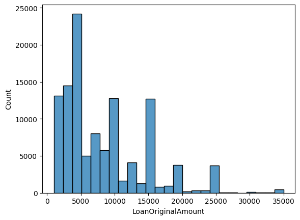

```python
sns.histplot(data=df, x='LoanOriginalAmount', bins=25, color='tab:blue');
```

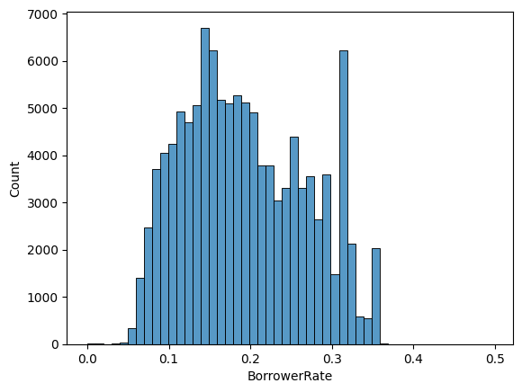

```python
sns.histplot(data=df, x='BorrowerRate', bins=50);
```

**Takeaway 1 (univariate)**:

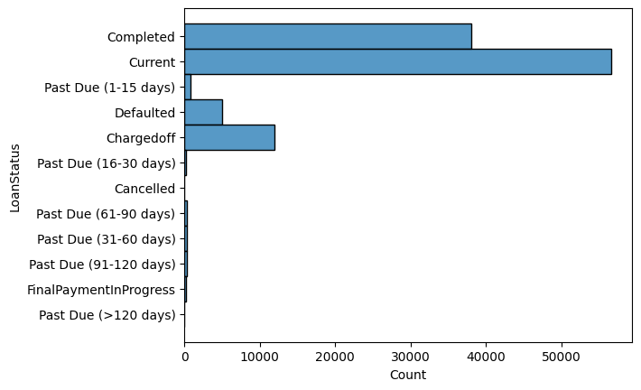

```python
sns.histplot(data=df, y='LoanStatus');
```

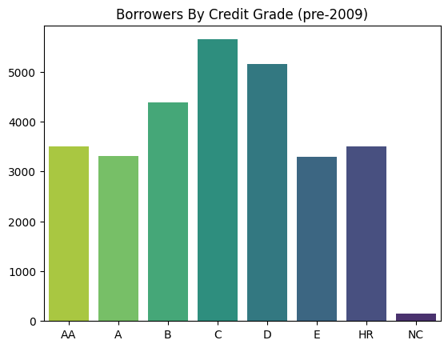

```python
sns.countplot(data=df, x='CreditGrade', palette='viridis_r')
plt.xlabel("")
plt.ylabel("")
plt.title('Borrowers By Credit Grade (pre-2009)');
```

**Takeaway 2 (univariate)**:

- Most of the loans are completed or current. There are very few loans in status defaulted or any of the past-due timebuckets. Some of the loans are Chargedoff.
- Creditgrade is widely distributed, with the highest count of borrowers placed in credit category C and D. Very few borrowers have an NC rating. Note: this is pre-2009 data.

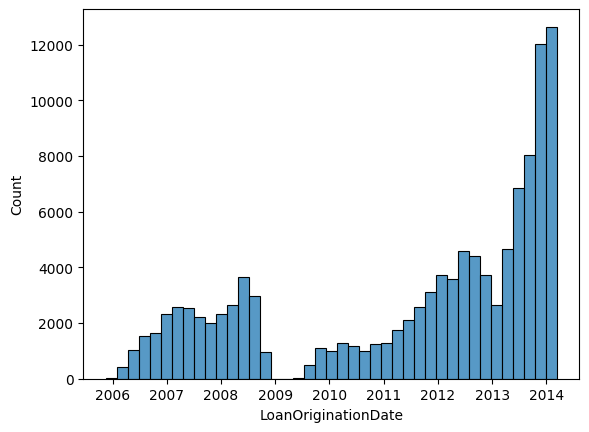

```python
sns.histplot(data=df, x='LoanOriginationDate', color='tab:blue');
```

[figure not shown]

```python
plt.figure(figsize=(8,4))
ax = sns.countplot(data=df, x='IncomeRange', color='tab:blue')

# Add percentages to the plot
total = float(len(df))
for p in ax.patches:
    height = p.get_height()+800
    ax.text(p.get_x() + p.get_width() / 2., height + 3, '{:1.2f}%'.format((height / total) * 100),
            ha="center")

# Show plot and hide spines #
ax.spines['top'].set_visible(False)
ax.spines['right'].set_visible(False)
plt.xticks(rotation=35)
plt.title('IncomeRange distribution with percentages', y=1.15)
plt.xlabel("")
plt.show()
```

**Takeaway 3 (univariate)**:

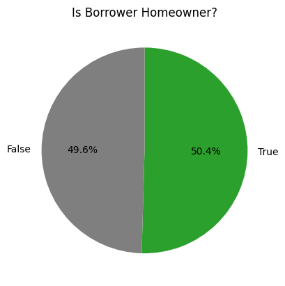

```python
sorted_counts = df.IsBorrowerHomeowner.value_counts()
plt.pie(sorted_counts, labels=sorted_counts.index, startangle = 90, counterclock=False, autopct='%1.1f%%',
       colors=['tab:green', 'tab:grey'])
plt.title('Is Borrower Homeowner?');
```

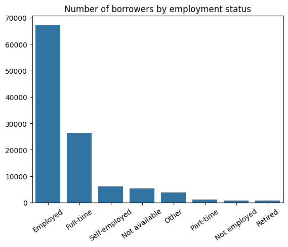

```python
#sorted_df = df.sort_by(Employment)
sns.countplot(data=df, x='EmploymentStatus', color='tab:blue',
              order=['Employed', 'Full-time', 'Self-employed',
                                                    'Not available', 'Other', 'Part-time', 'Not employed', 'Retired'])
plt.xticks(rotation=35)
plt.title('Number of borrowers by employment status')
plt.xlabel("")
plt.ylabel("");
```

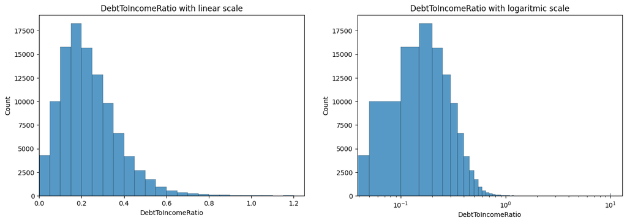

```python
# Two plots in one figure #
fig, (ax1, ax2) = plt.subplots(1,2,figsize=(16,5))

# Left plot: DebtToIncomeRatio with linear scale
ax1 = sns.histplot(data=df, x='DebtToIncomeRatio', bins=200, ax=ax1)
ax1.set_xlim(0,1.25)
ax1.set_title('DebtToIncomeRatio with linear scale')

# Right plot: DebtToIncomeRatio with logaritmic scale
ax2 = sns.histplot(data=df, x='DebtToIncomeRatio', bins=200, ax=ax2)
ax2.set_xscale('log')
ax2.set_title('DebtToIncomeRatio with logaritmic scale');
```

**Takeaway 4 (univariate)**:

- 50.4% of the borrowers are homeowners, whileas 49,6% are not.
- Most of the borrowers are employed or working full-time. Some are self-employed or working part-time, while a small minority is not employed or retired.
- The DebtToIncome range lies between 0 and 10, but most of the borrowers have a rate between 0 and 0.6. A ratio between 0.1 and 0.3 is most frequent. The plot on the left only displays loans with rate < 1.25, while the plot on the right displays everything, but on a logarithmic scale.

## Bivariate Exploration

In this section, we will investigate relationships between pairs of variables our data. The variables are already introduced during univariate exploration.

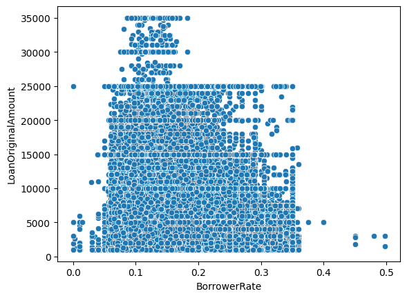

```python
sns.scatterplot(data=df, x='BorrowerRate', y='LoanOriginalAmount');
```

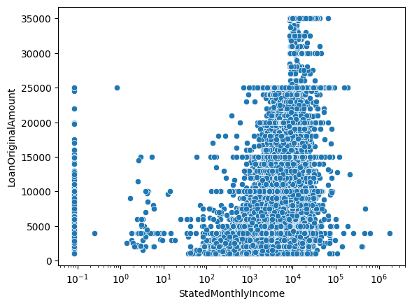

```python
ax = sns.scatterplot(data=df, x='StatedMonthlyIncome', y='LoanOriginalAmount')
ax.set_xscale('log')
```

**Takeaway 1 (bivariate)**:

- BorrowerRate and LoanOriginalAmount has a box-like shape, which means there is no clear trend between these two features. However, it is interesting to note that the highest borrowerrates are for very low loan amounts. Also, the highest loan amounts have quite low borrowerrates (most points below a rate of 0.2). This gives us an impression of good borrowers can loan high with good conditions, while bad borrowers can be forced to loan low with bad conditions.
- StatedMonthlyIncome and LoanOriginalAMount has a skewed-like shape. A vertical line of points are at 10^-1, and does not tell us anything (perhaps bad data). The data between 10^2 and 10^^6 tells us something different. The highest loan amounts (loans > 25k) are only seen for StatedMonthlyIncome above 10^4. This gives us an impression of strict criterias for the highest of loans. We also see horizontal stripes of data at LoanOriginalAmount of 5k, 10k, 15k, 20k and 25k. This gives us the impression either credit limits or searched for credit are given at certain intervals.

Next we will look at violin plots to describe relationships between quantitative and qualitative variables.

```python
def Loan_plots(var1):
    '''Function which takes as input a quantiative variable (preferably LoanOriginalAmount or BorrowerRate)
    and provides as output 4 violin-type plots for IsBorrowerHomeOwner, CreditGrade, EmploymentStatus and IncomeRange'''

    fig, ((ax1, ax2), (ax3, ax4)) = plt.subplots(2,2, figsize=(14,10))

    # Ax1: Plot 1
    ax1.set_title(f'{var1} by IsBorrowerHomeowner')
    ax1 = sns.violinplot(data=df, y=var1, x='IsBorrowerHomeowner', color='tab:blue', inner='quartile', ax=ax1)
    ax1.set(xlabel=None)
    [l.set_color('lightgrey') for l in ax1.lines]

    # Ax2: Plot 2
    ax2 = sns.violinplot(data=df, y=var1, x='CreditGrade', color='tab:blue', inner='quartile', ax=ax2)
    ax2.set_title(f'{var1} by CreditGrade')
    ax2.set(xlabel=None, ylabel=None)
    [l.set_color('lightgrey') for l in ax2.lines]

    # Ax3: Plot 3
    ax3 = sns.violinplot(data=df, y=var1, x='EmploymentStatus', color='tab:blue', inner='quartile', ax=ax3)
    ax3.set_title(f'{var1} by EmploymentStatus')
    ax3.set(xlabel=None)
    ax3.tick_params(axis='x', rotation=35)
    [l.set_color('lightgrey') for l in ax3.lines]

    # Ax4: Plot 4
    ax4 = sns.violinplot(data=df, y=var1, x='IncomeRange', color='tab:blue', inner='quartile', ax=ax4)
    ax4.set_title(f'{var1} by IncomeRange')
    ax4.set(xlabel=None, ylabel=None)
    ax4.tick_params(axis='x', rotation=35)
    [l.set_color('lightgrey') for l in ax4.lines]
```

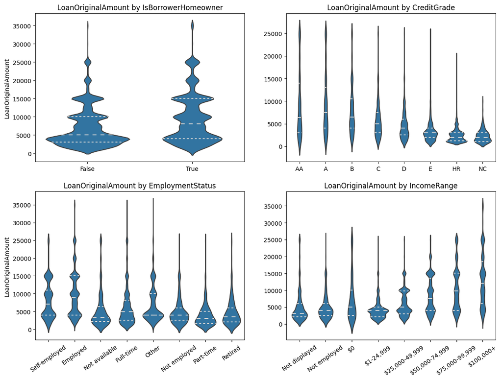

```python
Loan_plots('LoanOriginalAmount')
```

**Takeaway 2 (bivariate)**: Above we plotted 4 violin plots, each with LoanOriginalAmount against another feature. Let's explore some of the distributions.

- IsBorrowerHomeowner has an interesting distribution for True and False. False has the lowest quantiles, with the highest distribution with a LoanOriginalAmount around 5k. We see the same distribution here as before, in that pockets of distributions also appear at rounded values of 10k, 15k, 20k and 25k. For IsBorrowerHomeowner=True, we find that the median of LoanOriginalAmount is noticably higher. There are fewer observations with loan amounts less than 5k, but more observations at 15k, 20k, 25k and 35k. This gives us the indication that being a homeowner will affect what loan amount you are getting (perhaps the home acting as security here for the borrower, thus giving the borrower a better rate).
- The CreditGrade violinplot only shows us data pre-2009, but also gives us some interesting insights. On one hand, grades "AA" and "A" are so similar that we don't spot any noticable difference, but comparing distributions for those two grades to the "B" and "C" distributions, we spot a noticable difference in that "B" and "C" are worse off on the loan. Overall there is a noticable trend from grades "AA" all the way to "NC" in that the worse the CreditGrade gets, the denser the distribution gets at the low-end of LoanOriginalAmount, and the shorter the high-tail gets. From this we draw the insight that a good CreditGrade will increase a borrowers chance for a higher loan, while a bad rating will give you a bad chance.
- For EmploymentStatus we spot something similar: being "Self-employed" or "Employed" will increase your chances for a high loan, while working "part-time", "not employed" or "retired" will lower your chances (observed by distributions and tail heights).
- For IncomeRange we see the same type of trend. A high income (50k-75k, 75k-100k or 100k+) has a widely distributed LoanOriginalAmount, while low income (0k, 0k-25k) and no data (not displayed, not employed) has a higher low-end distribution.

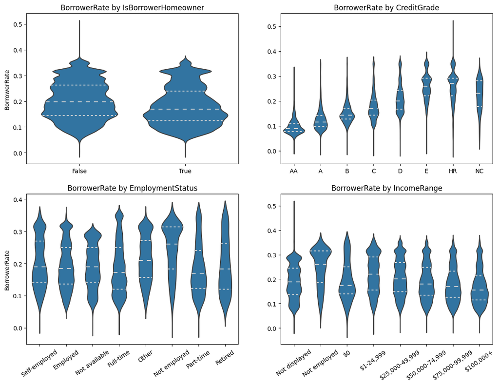

```python
Loan_plots('BorrowerRate')
```

**Takeaway 3 (bivariate)**: We will here look at the same 4 violin plots, but from a BorrowerRate perspective.

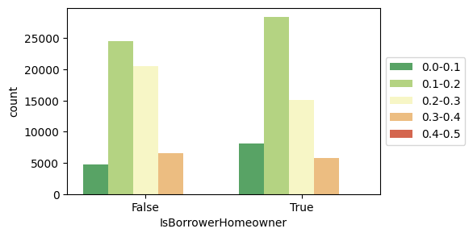

```python
plt.figure(figsize=(5,3))
ax = sns.countplot(data=df, x='IsBorrowerHomeowner', hue='BorrowerRateRange', palette='RdYlGn_r')
ax.legend(loc='center left', bbox_to_anchor=(1,0.5));
```

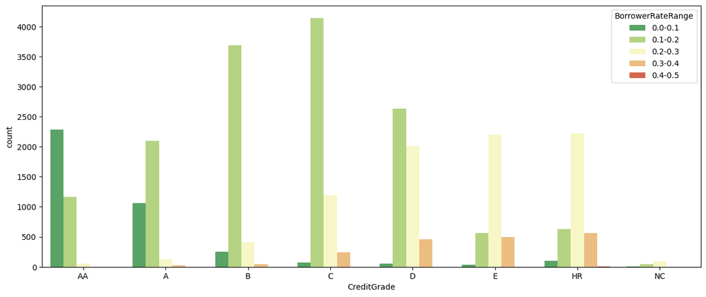

```python
plt.figure(figsize=(15,6))
sns.countplot(data=df, x='CreditGrade', hue='BorrowerRateRange', palette='RdYlGn_r');
plt.title('');
```

**Takeaway 4 (bivariate)**: This time we have a look at the BorrowerRateRange we feature engineered earlier in this report.

- IsBorrowerHomeowner/BorrowerRateRange: Similar distributions as before. For the IsBorrowerHomeowner=True category there are more borrowers with very low rate-ranges (0.0-0.1 and 0.1-0.2) , and fewer individuals in comparison for bad rate-ranges (0.2-0.3 and 0.3-0.4). This gives us the same impression again that being a homeowner increases your chances of a good BorrowerRate.
- CreditGrade/BorrowerRateRange: The "AA" rated almost without exceptions have an exceptional BorrowerRate inbetween 0.0 and 0.1 (most observations) or 0.1 and 0.2. We see a worsening trend across the scale from "AA" to "HR". Having a CreditGrade of "D" or "E" will earn you a high chance of a rate inbetween 0.2 and 0.3 with a noticable chance of a rate higher than 0.3.

Next we will move on to multivariate exploration, where we will explore some of these relationships even further.

## Multivariate Exploration

In this section we will explore even more complex patterns between our features of interest by using multivariate plots.

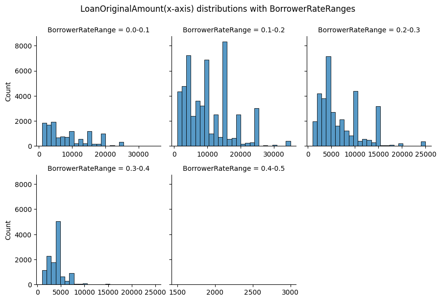

```python
g = sns.FacetGrid(data=df, col='BorrowerRateRange', col_wrap=3, sharey=True, sharex=False)
ax = g.map(sns.histplot, 'LoanOriginalAmount', bins=25)
ax.fig.suptitle('LoanOriginalAmount(x-axis) distributions with BorrowerRateRanges', y=1.05);
ax.set(xlabel=None);
```

**Takeaway 1 (multivariate)**: The BorrowerRateRange of 0.0-0.1 is widely distributed on the x-axis, but fewer observations exists from loan amounts of 10k and onwards. The raterange of 0.1-0.2 has a lot more observations, but is similar in that spikes of loans appear at rounded values of 10k, 15k, 20k and 25k. For the range 0.2-0.3 there are even more observations at the lower end of the LoanOriginalAmount spectrum. For the highest raterange there are almost only observations up until a loan amount of 10k.

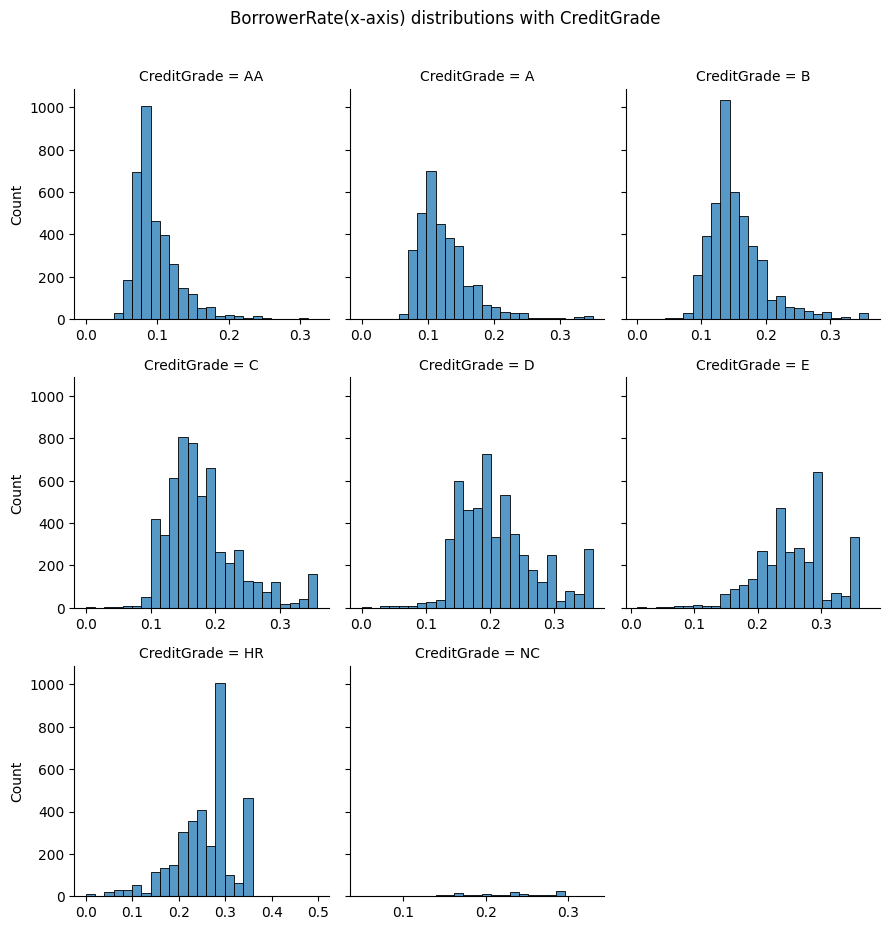

```python
g = sns.FacetGrid(data=df, col='CreditGrade', col_wrap=3, sharey=True, sharex=False)
ax = g.map(sns.histplot, 'BorrowerRate', bins=25)
ax.fig.suptitle('BorrowerRate(x-axis) distributions with CreditGrade', y=1.05);
ax.set(xlabel=None);
```

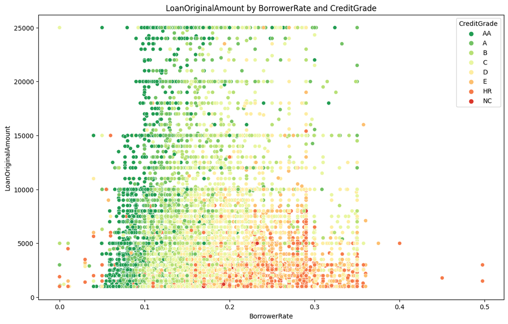

```python
creditdf= df[['BorrowerRate', 'LoanOriginalAmount', 'CreditGrade']].dropna()
creditdf = creditdf.sample(n=15000, random_state=1)
plt.figure(figsize=(13,8))
ax = sns.scatterplot(data=creditdf, x='BorrowerRate', y='LoanOriginalAmount', hue='CreditGrade', palette='RdYlGn_r')
ax.set_title("LoanOriginalAmount by BorrowerRate and CreditGrade");
```

**Takeaway 3 (multivariate)**:

- Moving on with our multivariate exploration, we are looking to compare BorrowerRate, LoanOriginalAmount and CreditGrade. From the plot we draw the insight that for the most part, a good grade will yield you a good BorrowerRate. However, this insight is slightly more nuanced now with LoanOriginalAmount. If you have an exceptional rate of "AA", you will get a better rate for a low loan amount than for a high loan amount (seen with close distributions at the low loan spectrum of < 5k, compared to a slightly shifted rate at the high end of the spectrum, > 20k).
- The bad CreditGrades ("D", "E", "HR" and "NC") we see are for the most part shifted to the right on the BorrowerRate spectrum, most loans with a rate beyond 0.2. On the y-axis, these groups are also more often than not on the lower end of the scale, with loans below 10k. However, there are also exceptions seen in the plot, with red dots on the left side of the plot among the green, and quite a few "D" rated beyond 15k aswell on the y-axis.

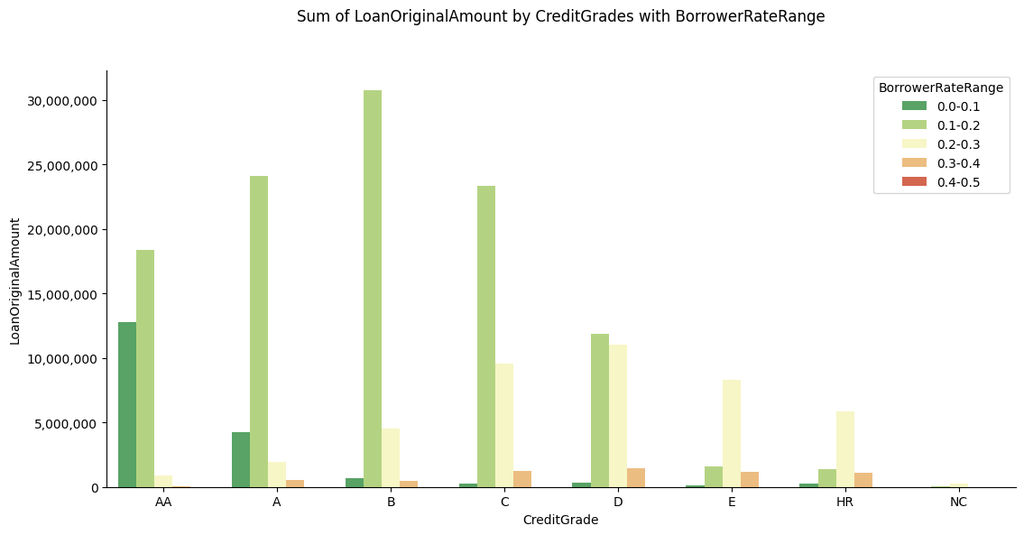

```python
plt.figure(figsize=(13,6))
sum_values = df.groupby(['CreditGrade', 'BorrowerRateRange'])['LoanOriginalAmount'].sum()
sum_values = sum_values.reset_index()
ax = sns.barplot(data=sum_values, x='CreditGrade', y='LoanOriginalAmount', hue='BorrowerRateRange', palette='RdYlGn_r')
ax.yaxis.set_major_formatter(ticker.StrMethodFormatter('{x:,.0f}'))
ax.spines['top'].set_visible(False)
ax.spines['right'].set_visible(False)
ax.set_title('Sum of LoanOriginalAmount by CreditGrades with BorrowerRateRange', y=1.10);
```

**Takeaway 4 (multivariate)**: In this plot we extended the count-plot we had in the bivariate analysis, to a sum plot with LoanOriginalAmount on the y-axis. Note again that we are looking at the sum of pre-2009 data here.

- Observation 1: CreditGrade "AA" once again almost without exception have rate-ranges of 0.0-0.1 and 0.1-0.2. We observe a difference from the bivariate plot here in that the sum is higher for the worse rate-range for "AA" loans. This confirms what we saw in the previous scatterplot in that even though there are many loans with low loan amounts for the best rate-range, these loans are on average lower in LoanOriginalAmount compared to the 2nd best rate-range.
- Observation 2: For CreditGrade "A" the loan sum is higher for 0.1-0.2 than for the bivariate plot. However, for category "D" and "E", the sums for ranges 0.3-0.4 are lower than for the countplot. This confirms our previous suspicion that for the worst rate-loans, higher LoanOriginalAmount is more rare.

## Conclusions

- The worse the credit grade, the lower the chance for a good borrower rate and high loan amount. A grade worse than "B" will give the borrower a very low chance for the best rate.
- Being a homeowner increases your chance for a higher loan, and also gives the borrower a better chance for a good borrower rate.
- Being employed is a good thing, both for the borrowers rate and for getting a higher loan amount.
- The borrowers income will affect the chance for a low rate and a high loan amount.

Finally, let's revisit our research questions.

##### Does it matter who you are for what loan amount you are getting?

Yes it does. If you are a high-earning professional, with a house and good liquidity you are more likely to get a good rate and be approved for a high loan amount.

##### Who gets the best borrowerrate and why?

An individual scoring well on analyzed attributes throughout this report has a higher chance for a good borrowerrate. The best rates are generally given to those with "AA" or "A" ratings who also do well on other features. There could be many reasons for this, some include probability of default for a given loan, borrower value to company and more. As we saw in our visuals, there were some exceptions to this general trend. A possible explanation for this could be special membership qualifying for good terms or similar, bypassing the regular rate-rules.